# BellaBeat Case Study

poorna

2024-06-07

## Bellabeat Case Study — Google Data Analytics

### Introduction

Bellabeat is a technology-driven wellness company that focuses on developing cutting-edge products that enable women to live more balanced, healthier lives. Bellabeat, which was founded in 2014 by Urska Srsen and Sandro Mur, rose to fame with its main offering, the Bellabeat Leaf, a wearable that monitors women’s stress levels, sleep patterns, and menstrual cycles.The goal of the organization is to use technology to support holistic wellbeing, with an emphasis on women’s health in particular. Bellabeat’s products are renowned for their sophisticated designs that easily integrate into commonplace accessories like jewelry or clips, giving them a dual purpose of being fashionable and functional.

Bellabeat has added other wellness-focused products and services to its lineup in addition to the Leaf, like the Bellabeat app, which offers individualized advice and insights based on user data, and the Bellabeat Spring water bottle, which monitors hydration levels.

Bellabeat has gained recognition for its inventive products as well as for its dedication to advancing a holistic strategy for health and wellness that includes stress reduction, mental health, and physical exercise. Bellabeat continues to encourage women to take charge of their health and well-being through its products, bridging the gap between wellness and technology in an approachable and fashionable manner.

### Ask Phase

#### Business Task

The key business task is to analyze user data to understand engagement patterns, track health metrics, and optimize features. By evaluating user demographics, retention rates, and market trends, Bellabeat aims to enhance its products, improve user satisfaction, and drive business growth through data-driven insights.

#### Business Questions

1.What are the latest patterns in smart device usage?

2.How might these patterns relate to Bellabeat’s clientele?

3.How are users reacting to new smart device trends, and how do these trends impact Bellabeat’s product and marketing strategies?

#### Key Stakeholders:

- Urška Sršen - Bellabeat’s co founder and Chief Creative Officer
- Sandro Mur - Mathematician and Bellabeat cofounder; key member of the Bellabeat executive team
- Bellabeat marketing analytics team - A team of data analysts responsible for collecting, analyzing, and reporting data that helps guide Bellabeat’s marketing strategy.

### Prepare Phase

#### ROCCC Analysis

Reliable: The absence of demographic data raises concerns about the data’s reliability as it may affect the sample’s representativeness and correctness. It is difficult to determine whether the data is genuinely representative of the larger population in the absence of demographic information.

Originality: The fact that the data was gathered from Amazon Mechanical Turk, a third-party source, contributes to its low originality. Although this platform is frequently used to gather data, it casts doubt on the veracity and caliber of the answers. Furthermore, the uniqueness of the dataset may be further reduced if it has been utilized in several research or analyses.

Comprehensive: The data is quite thorough since it includes individual health information, which permits in-depth examination and new perspectives on a range of wellness and health-related topics. There are many opportunities to answer business challenges and draw insightful conclusions thanks to the richness of the data.

Cited: Due to Amazon Mechanical Turk’s extensive documentation, the data has a high citation count. Clear documentation of the data source improves openness and makes it possible for any analysis or study that uses the dataset to provide due credit.

### Process phase

R Studio was used to complete this analysis because of the many packages and data visualization features available to explore the data with.

```r
options(repos = c(CRAN = "https://cloud.r-project.org"))
install.packages("tidyverse")
install.packages("here")
install.packages("janitor")
install.packages("dplyr")
install.packages("skimr")
install.packages("ggrepel")
library(ggrepel)
library("tidyverse")
library("here")
library("dplyr")
library("janitor")
library("skimr")
```

The files were imported into R Studio and the data frames were created with simplified names.

```r
setwd("C:/Users/FIONA_SHREK/Documents/Bellabeat/mturkfitbit_export_4.12.16-5.12.16/Fitabase Data 4.12.16-5.12.16")


library(readr)
dailyActivity <- read_csv("dailyActivity_merged.csv")
dailyCalories <- read_csv("dailyCalories_merged.csv")
dailyIntensities <- read_csv("dailyIntensities_merged.csv")
dailySteps <- read_csv("dailySteps_merged.csv")
heartrate_seconds <- read_csv("heartrate_seconds_merged.csv")
minuteMETsNarrow<- read_csv("minuteMETsNarrow_merged.csv")
sleepDay <- read_csv("sleepDay_merged.csv")
weightLogInfo <- read_csv("weightLogInfo_merged.csv")
h_intensitie  <- read.csv("hourlyIntensities_merged.csv")
hourly_calories <- read.csv("hourlyCalories_merged.csv")
hourly_steps <- read.csv("hourlySteps_merged.csv")
```

```r
head(dailyActivity)
```

```
## # A tibble: 6 × 15
##           Id ActivityDate TotalSteps TotalDistance TrackerDistance
##        <dbl> <chr>             <dbl>         <dbl>           <dbl>
## 1 1503960366 4/12/2016         13162          8.5             8.5
## 2 1503960366 4/13/2016         10735          6.97            6.97
## 3 1503960366 4/14/2016         10460          6.74            6.74
## 4 1503960366 4/15/2016          9762          6.28            6.28
## 5 1503960366 4/16/2016         12669          8.16            8.16
## 6 1503960366 4/17/2016          9705          6.48            6.48
## # ℹ 10 more variables: LoggedActivitiesDistance <dbl>,
## #   VeryActiveDistance <dbl>, ModeratelyActiveDistance <dbl>,
## #   LightActiveDistance <dbl>, SedentaryActiveDistance <dbl>,
## #   VeryActiveMinutes <dbl>, FairlyActiveMinutes <dbl>,
## #   LightlyActiveMinutes <dbl>, SedentaryMinutes <dbl>, Calories <dbl>
```

```r
head(dailyCalories)
```

```
## # A tibble: 6 × 3
##           Id ActivityDay Calories
##        <dbl> <chr>          <dbl>
## 1 1503960366 4/12/2016       1985
## 2 1503960366 4/13/2016       1797
## 3 1503960366 4/14/2016       1776
## 4 1503960366 4/15/2016       1745
## 5 1503960366 4/16/2016       1863
## 6 1503960366 4/17/2016       1728
```

```r
head(dailyIntensities)
```

```
## # A tibble: 6 × 10
##         Id ActivityDay SedentaryMinutes LightlyActiveMinutes FairlyActiveMinutes
##      <dbl> <chr>                  <dbl>                <dbl>               <dbl>
## 1   1.50e9 4/12/2016                728                  328                  13
## 2   1.50e9 4/13/2016                776                  217                  19
## 3   1.50e9 4/14/2016               1218                  181                  11
## 4   1.50e9 4/15/2016                726                  209                  34
## 5   1.50e9 4/16/2016                773                  221                  10
## 6   1.50e9 4/17/2016                539                  164                  20
## # ℹ 5 more variables: VeryActiveMinutes <dbl>, SedentaryActiveDistance <dbl>,
## #   LightActiveDistance <dbl>, ModeratelyActiveDistance <dbl>,
## #   VeryActiveDistance <dbl>
```

```r
head(dailySteps)
```

```
## # A tibble: 6 × 3
##           Id ActivityDay StepTotal
##        <dbl> <chr>           <dbl>
## 1 1503960366 4/12/2016       13162
## 2 1503960366 4/13/2016       10735
## 3 1503960366 4/14/2016       10460
## 4 1503960366 4/15/2016        9762
## 5 1503960366 4/16/2016       12669
## 6 1503960366 4/17/2016        9705
```

```r
head(heartrate_seconds)
```

```
## # A tibble: 6 × 3
##           Id Time                 Value
##        <dbl> <chr>                <dbl>
## 1 2022484408 4/12/2016 7:21:00 AM    97
## 2 2022484408 4/12/2016 7:21:05 AM   102
## 3 2022484408 4/12/2016 7:21:10 AM   105
## 4 2022484408 4/12/2016 7:21:20 AM   103
## 5 2022484408 4/12/2016 7:21:25 AM   101
## 6 2022484408 4/12/2016 7:22:05 AM    95
```

```r
head(minuteMETsNarrow)
```

```
## # A tibble: 6 × 3
##           Id ActivityMinute         METs
##        <dbl> <chr>                 <dbl>
## 1 1503960366 4/12/2016 12:00:00 AM    10
## 2 1503960366 4/12/2016 12:01:00 AM    10
## 3 1503960366 4/12/2016 12:02:00 AM    10
## 4 1503960366 4/12/2016 12:03:00 AM    10
## 5 1503960366 4/12/2016 12:04:00 AM    10
## 6 1503960366 4/12/2016 12:05:00 AM    12
```

```r
head(sleepDay)
```

```
## # A tibble: 6 × 5
##           Id SleepDay        TotalSleepRecords TotalMinutesAsleep TotalTimeInBed
##        <dbl> <chr>                       <dbl>              <dbl>          <dbl>
## 1 1503960366 4/12/2016 12:0…                 1                327            346
## 2 1503960366 4/13/2016 12:0…                 2                384            407
## 3 1503960366 4/15/2016 12:0…                 1                412            442
## 4 1503960366 4/16/2016 12:0…                 2                340            367
## 5 1503960366 4/17/2016 12:0…                 1                700            712
## 6 1503960366 4/19/2016 12:0…                 1                304            320
```

```r
head(weightLogInfo)
```

```
## # A tibble: 6 × 8
##           Id Date       WeightKg WeightPounds   Fat   BMI IsManualReport   LogId
##        <dbl> <chr>         <dbl>        <dbl> <dbl> <dbl> <lgl>            <dbl>
## 1 1503960366 5/2/2016 …     52.6         116.    22  22.6 TRUE           1.46e12
## 2 1503960366 5/3/2016 …     52.6         116.    NA  22.6 TRUE           1.46e12
## 3 1927972279 4/13/2016…    134.          294.    NA  47.5 FALSE          1.46e12
## 4 2873212765 4/21/2016…     56.7         125.    NA  21.5 TRUE           1.46e12
## 5 2873212765 5/12/2016…     57.3         126.    NA  21.7 TRUE           1.46e12
## 6 4319703577 4/17/2016…     72.4         160.    25  27.5 TRUE           1.46e12
```

```r
sum(duplicated(sleepDay))
```

```
## [1] 3
```

```r
sleepDay_cleaned <- sleepDay %>%
  distinct() %>%
  drop_na()

sum(duplicated(sleepDay_cleaned))
```

```
## [1] 0
```

```r
sum(duplicated(weightLogInfo))
```

```
## [1] 0
```

```r
weightLogInfo_cleaned <- weightLogInfo %>%
  distinct() %>%
  drop_na()

sum(duplicated(weightLogInfo_cleaned))
```

```
## [1] 0
```

```r
sum(duplicated(dailyActivity))
```

```
## [1] 0
```

```r
dailyActivity_cleaned <- dailyActivity %>%
  distinct() %>%
  drop_na()

sum(duplicated(dailyActivity_cleaned))
```

```
## [1] 0
```

```r
sum(duplicated(dailyCalories))
```

```
## [1] 0
```

```r
dailyCalories_cleaned <- dailyCalories %>%
  distinct() %>%
  drop_na()

sum(duplicated(dailyCalories_cleaned))
```

```
## [1] 0
```

```r
sum(duplicated(dailyIntensities))
```

```
## [1] 0
```

```r
dailyIntensities_cleaned <- dailyIntensities %>%
  distinct() %>%
  drop_na()

sum(duplicated(dailyIntensities_cleaned))
```

```
## [1] 0
```

```r
sum(duplicated(dailySteps))
```

```
## [1] 0
```

```r
dailySteps_cleaned <- dailySteps %>%
  distinct() %>%
  drop_na()

sum(duplicated(dailySteps_cleaned))
```

```
## [1] 0
```

```r
sum(duplicated(heartrate_seconds))
```

```
## [1] 0
```

```r
heartrate_seconds_cleaned <- heartrate_seconds %>%
  distinct() %>%
  drop_na()

sum(duplicated(heartrate_seconds_cleaned))
```

```
## [1] 0
```

```r
sum(duplicated(minuteMETsNarrow))
```

```
## [1] 0
```

```r
minuteMETsNarrow_cleaned <- minuteMETsNarrow %>%
  distinct() %>%
  drop_na()

sum(duplicated(minuteMETsNarrow_cleaned))
```

```
## [1] 0
```

```r
sum(duplicated(h_intensitie))
```

```
## [1] 0
```

```r
h_intensitie <- h_intensitie %>%
  distinct() %>%
  drop_na()
sum(duplicated(h_intensitie))
```

```
## [1] 0
```

```r
sum(duplicated(hourly_calories))
```

```
## [1] 0
```

```r
hourly_calories <- hourly_calories %>%
  distinct() %>%
  drop_na()
sum(duplicated(hourly_calories))
```

```
## [1] 0
```

```r
sum(duplicated(hourly_steps))
```

```
## [1] 0
```

```r
hourly_steps <- hourly_steps %>%
  distinct() %>%
  drop_na()
sum(duplicated(hourly_steps))
```

```
## [1] 0
```

```r
dailyActivity_cleaned$Date<-as.Date(dailyActivity_cleaned$ActivityDate, "%m/%d/%Y")
dailyActivity_cleaned$Id<-as.character(dailyActivity_cleaned$Id)

h_intensitie$ActivityHour=as.POSIXct(h_intensitie$ActivityHour, format="%m/%d/%Y %I:%M:%S %p", tz=Sys.timezone())
h_intensitie$time <- format(h_intensitie$ActivityHour, format = "%H:%M:%S")
h_intensitie$date <- format(h_intensitie$ActivityHour, format = "%m/%d/%y")

hourly_calories$ActivityHour=as.POSIXct(hourly_calories$ActivityHour, format="%m/%d/%Y %I:%M:%S %p", tz=Sys.timezone())
hourly_calories$time <- format(hourly_calories$ActivityHour, format = "%H:%M:%S")
hourly_calories$date <- format(hourly_calories$ActivityHour, format = "%m/%d/%y")

sleepDay_cleaned$SleepDay=as.POSIXct(sleepDay_cleaned$SleepDay, format="%m/%d/%Y %I:%M:%S %p", tz=Sys.timezone())
sleepDay_cleaned$Date <- format(sleepDay_cleaned$SleepDay, format = "%m/%d/%y")
```

### Analyze Phase

This section involves transforming and organizing the cleaned data to identify patterns and address key questions relevant to our business task. The results were visualized and interpreted to facilitate data-driven decisions.

#### Finding the number of participants

```r
print(paste(n_distinct(dailyActivity_cleaned$Id), "unique individuals in activity"))
```

```
## [1] "33 unique individuals in activity"
```

```r
print(paste(n_distinct(h_intensitie$Id), "unique individuals in intensities"))
```

```
## [1] "33 unique individuals in intensities"
```

```r
print(paste(n_distinct(sleepDay_cleaned$Id), "unique individuals in sleep"))
```

```
## [1] "24 unique individuals in sleep"
```

```r
print(paste(n_distinct(weightLogInfo_cleaned$Id), "unique individuals in weight"))
```

```
## [1] "2 unique individuals in weight"
```

```r
print("-----Daily Calories-----")
```

```
## [1] "-----Daily Calories-----"
```

```r
dailyActivity_cleaned %>%
  select(Calories) %>%
  drop_na() %>%
  summary()
```

```
##     Calories
##  Min.   :   0
##  1st Qu.:1828
##  Median :2134
##  Mean   :2304
##  3rd Qu.:2793
##  Max.   :4900
```

```r
print("-----Daily Intensities-----")
```

```
## [1] "-----Daily Intensities-----"
```

```r
dailyActivity_cleaned %>%
  select(SedentaryMinutes, LightlyActiveMinutes, FairlyActiveMinutes, VeryActiveDistance) %>%
  drop_na() %>%
  summary()
```

```
##  SedentaryMinutes LightlyActiveMinutes FairlyActiveMinutes VeryActiveDistance
##  Min.   :   0.0   Min.   :  0.0        Min.   :  0.00      Min.   : 0.000
##  1st Qu.: 729.8   1st Qu.:127.0        1st Qu.:  0.00      1st Qu.: 0.000
##  Median :1057.5   Median :199.0        Median :  6.00      Median : 0.210
##  Mean   : 991.2   Mean   :192.8        Mean   : 13.56      Mean   : 1.503
##  3rd Qu.:1229.5   3rd Qu.:264.0        3rd Qu.: 19.00      3rd Qu.: 2.053
##  Max.   :1440.0   Max.   :518.0        Max.   :143.00      Max.   :21.920
```

```r
print("-----Daily Steps-----")
```

```
## [1] "-----Daily Steps-----"
```

```r
dailyActivity_cleaned %>%
  select(TotalSteps) %>%
  drop_na() %>%
  summary()
```

```
##    TotalSteps
##  Min.   :    0
##  1st Qu.: 3790
##  Median : 7406
##  Mean   : 7638
##  3rd Qu.:10727
##  Max.   :36019
```

```r
print("-----Daily Sleep-----")
```

```
## [1] "-----Daily Sleep-----"
```

```r
sleepDay_cleaned %>%
  select(TotalSleepRecords, TotalMinutesAsleep, TotalTimeInBed) %>%
  drop_na() %>%
  summary()
```

```
##  TotalSleepRecords TotalMinutesAsleep TotalTimeInBed
##  Min.   :1.00      Min.   : 58.0      Min.   : 61.0
##  1st Qu.:1.00      1st Qu.:361.0      1st Qu.:403.8
##  Median :1.00      Median :432.5      Median :463.0
##  Mean   :1.12      Mean   :419.2      Mean   :458.5
##  3rd Qu.:1.00      3rd Qu.:490.0      3rd Qu.:526.0
##  Max.   :3.00      Max.   :796.0      Max.   :961.0
```

This daily_activity summary shows the average user is taking 7638 steps a day, missing the recommended 10,000 steps for health by the CDC. On average, users are getting 21.16 minutes of very active or vigorous activity a day, this equates to 148.12 minutes a week. The CDC recommends 75 minutes of vigorous activity a week, so the typical Fitbit user is doing well in this area and achieving additional health benefits. In contrast, participants are averaging 991.2 minutes, or 16.52 hours of sedentary time a day! This is a significant amount of time and can lead to other health issues because the body functions best upright. Scientists have determined that 40 minutes of moderate to vigorous activity a day will balance out the effects of sitting up to 10 hours a day. Furthermore, this summary shows the average user is burning 2304 calories a day. Studies show the average person in the population burns 1800 calories a day, but burning 3500 is needed to lose a pound of weight. The Fitbit users in this case are burning more than the norm, and are on track to lose a few pounds a week if they so choose.

```r
print("-----Hourly Calories-----")
```

```
## [1] "-----Hourly Calories-----"
```

```r
hourly_calories %>%
  select(Calories) %>%
  drop_na() %>%
  summary()
```

```
##     Calories
##  Min.   : 42.00
##  1st Qu.: 63.00
##  Median : 83.00
##  Mean   : 97.39
##  3rd Qu.:108.00
##  Max.   :948.00
```

```r
print("-----Hourly Intensities-----")
```

```
## [1] "-----Hourly Intensities-----"
```

```r
h_intensitie %>%
  select(TotalIntensity, AverageIntensity) %>%
  drop_na() %>%
  summary()
```

```
##  TotalIntensity   AverageIntensity
##  Min.   :  0.00   Min.   :0.0000
##  1st Qu.:  0.00   1st Qu.:0.0000
##  Median :  3.00   Median :0.0500
##  Mean   : 12.04   Mean   :0.2006
##  3rd Qu.: 16.00   3rd Qu.:0.2667
##  Max.   :180.00   Max.   :3.0000
```

```r
print("-----Hourly Steps-----")
```

```
## [1] "-----Hourly Steps-----"
```

```r
hourly_steps %>%
  select(StepTotal) %>%
  drop_na() %>%
  summary()
```

```
##    StepTotal
##  Min.   :    0.0
##  1st Qu.:    0.0
##  Median :   40.0
##  Mean   :  320.2
##  3rd Qu.:  357.0
##  Max.   :10554.0
```

```r
heartrate_seconds_cleaned %>% select(Value) %>% summary()
```

```
##      Value
##  Min.   : 36.00
##  1st Qu.: 63.00
##  Median : 73.00
##  Mean   : 77.33
##  3rd Qu.: 88.00
##  Max.   :203.00
```

Despite the low number of users in the heart rate data frame, the average heartrate of 77 beats per minute (bpm) fits within the “normal” range. Normal is considered to be between 50 to 80 bpm for men, and 53 to 82 bpm for women. However, research suggests that it is more important for individuals to determine what is a normal and healthy heartrate for them, and not compare to population levels. This is because resting heart rates between different people can vary by as much as 70 bpm. Changes in resting heartrate over days can be a sign of infection, menstrual cycle effects, or other acute triggers. Thus, making heartrate a vital health characteristic to monitor.

```r
minuteMETsNarrow_cleaned %>%  select(METs) %>% summary()
```

```
##       METs
##  Min.   :  0.00
##  1st Qu.: 10.00
##  Median : 10.00
##  Mean   : 14.69
##  3rd Qu.: 11.00
##  Max.   :157.00
```

```r
weightLogInfo_cleaned %>%  select(WeightPounds,BMI) %>% summary()
```

```
##   WeightPounds        BMI
##  Min.   :116.0   Min.   :22.65
##  1st Qu.:126.9   1st Qu.:23.85
##  Median :137.8   Median :25.05
##  Mean   :137.8   Mean   :25.05
##  3rd Qu.:148.7   3rd Qu.:26.25
##  Max.   :159.6   Max.   :27.45
```

### Share phase

The RStudio ggplot() function was utilized to generate data visualizations that illustrate the patterns and trends identified within the data frames.

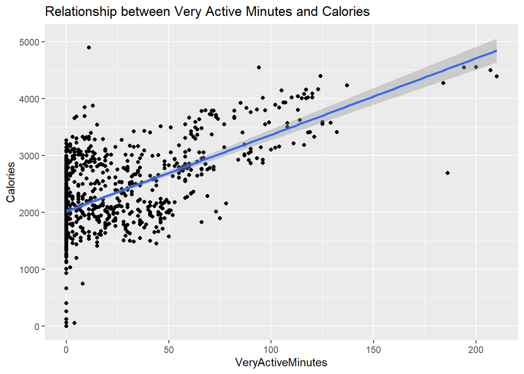

```r
ggplot(data = dailyActivity_cleaned) +
  geom_point(aes(x = VeryActiveMinutes, y = Calories)) +
  geom_smooth(aes(x = VeryActiveMinutes, y = Calories), method = "lm") +
  labs(title = "Relationship between Very Active Minutes and Calories")
```

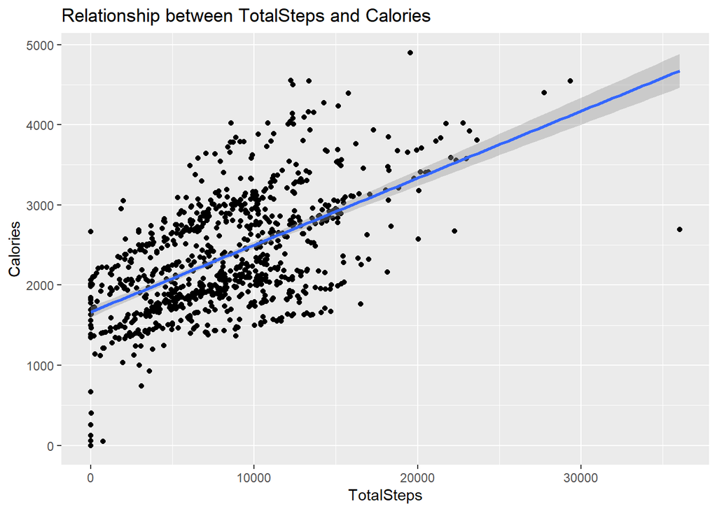

```r
ggplot(data = dailyActivity_cleaned) +
  geom_point(aes(x = TotalSteps, y = Calories)) +
  geom_smooth(aes(x = TotalSteps, y = Calories), method = "lm") +
  labs(title = "Relationship between TotalSteps and Calories")
```

The above plot depicts the overall steps taken each day and total calories burned have a positive correlation. This implies that Fitbit users burnt more calories the more steps they took.

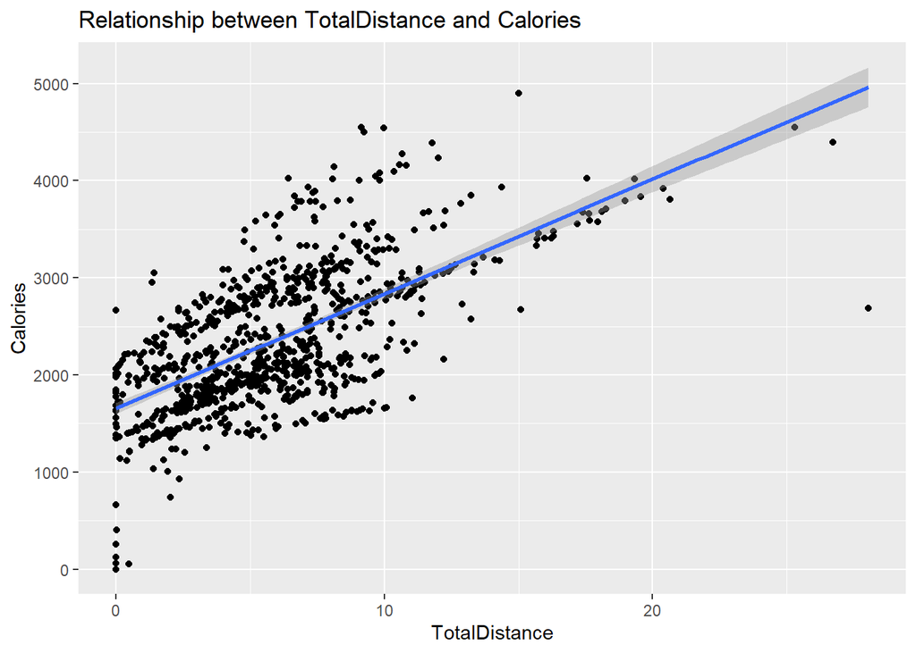

```r
ggplot(data = dailyActivity_cleaned) +
  geom_point(aes(x = TotalDistance, y = Calories)) +
  geom_smooth(aes(x = TotalDistance, y = Calories), method = "lm") +
  labs(title = "Relationship between TotalDistance and Calories")
```

The above plot shows a positive trend between total distance and total daily calories burned. As the participants moved a greater distance, the number of calories they burned also increased.

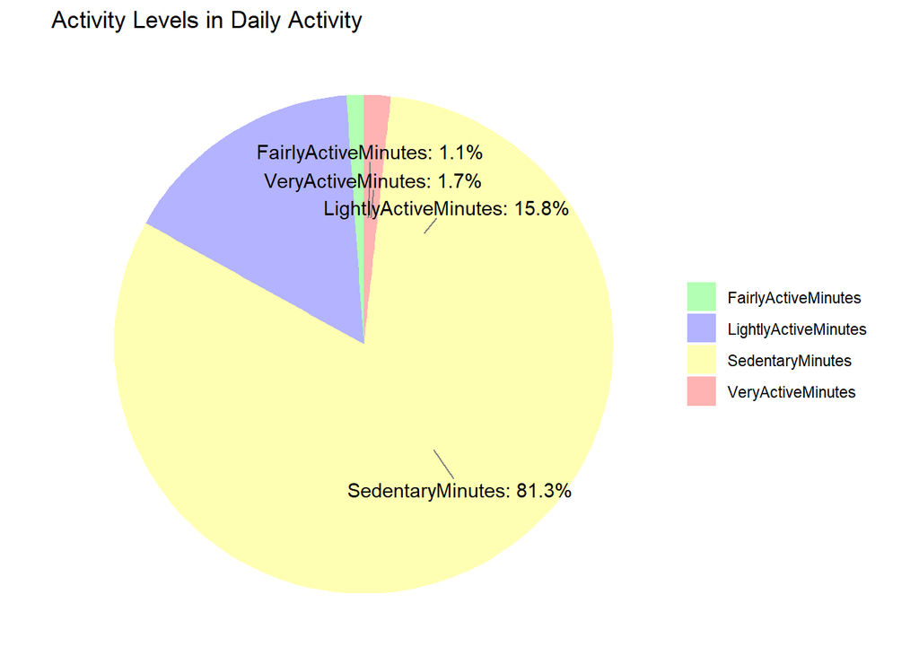

```r
activity_summary <- colSums(dailyActivity_cleaned[, c("VeryActiveMinutes", "FairlyActiveMinutes", "LightlyActiveMinutes", "SedentaryMinutes")])

activity_data <- data.frame(
  ActivityLevel = names(activity_summary),
  Minutes = activity_summary
)

activity_data <- activity_data %>%
  mutate(Percentage = round((Minutes / sum(Minutes)) * 100, 1))
activity_data$Label <- paste0(activity_data$ActivityLevel, ": ", activity_data$Percentage, "%")


custom_colors <- c("VeryActiveMinutes" = "#FFB3B3",
                  "FairlyActiveMinutes" = "#B3FFB3",
                  "LightlyActiveMinutes" = "#B3B3FF",
                  "SedentaryMinutes" = "#FFFFB3")



ggplot(activity_data, aes(x = "", y = Minutes, fill = ActivityLevel)) +
  geom_bar(width = 1, stat = "identity") +
  coord_polar(theta = "y") +
  labs(title = "Activity Levels in Daily Activity") +
  scale_fill_manual(values = custom_colors) +
  theme_void() +
  theme(legend.title = element_blank()) +
  geom_text_repel(aes(label = Label, y = Minutes / 2, x = 1),
                  direction = "y", nudge_x = 0.2, nudge_y = 0.2,
                  segment.color = "grey50", segment.size = 0.5)
```

#### Correlation between Activity Levels and Calories Burnt per Day

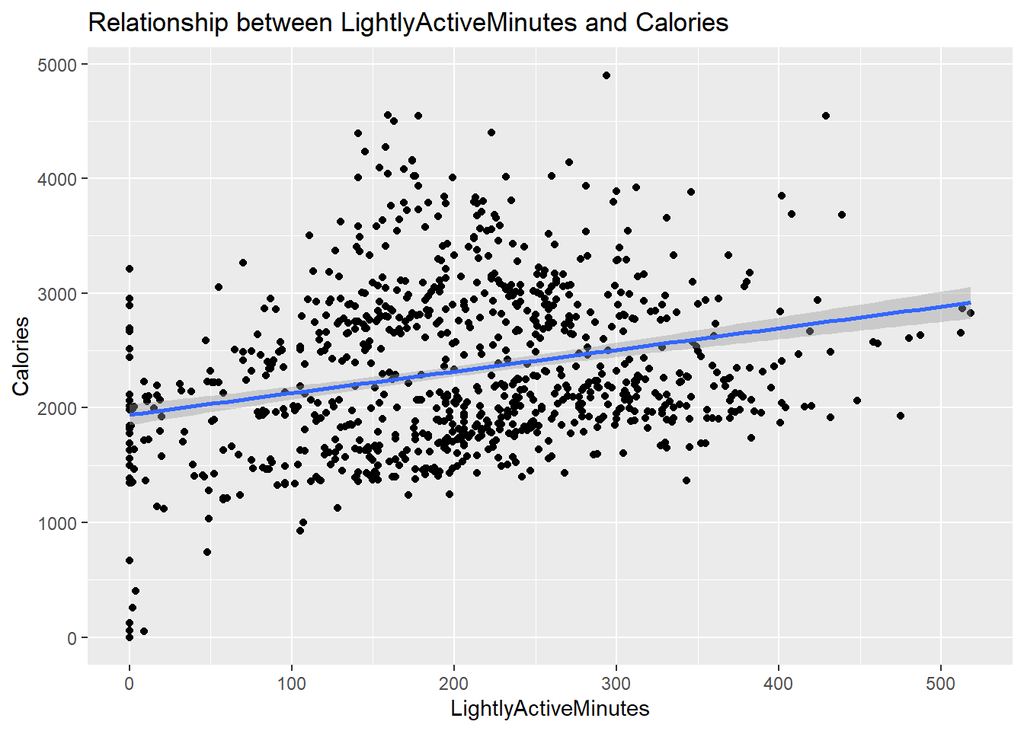

```r
ggplot(data = dailyActivity_cleaned) +
  geom_point(aes(x = LightlyActiveMinutes, y = Calories)) +
  geom_smooth(aes(x = LightlyActiveMinutes, y = Calories), method = "lm") +
  labs(title = "Relationship between LightlyActiveMinutes and Calories")
```

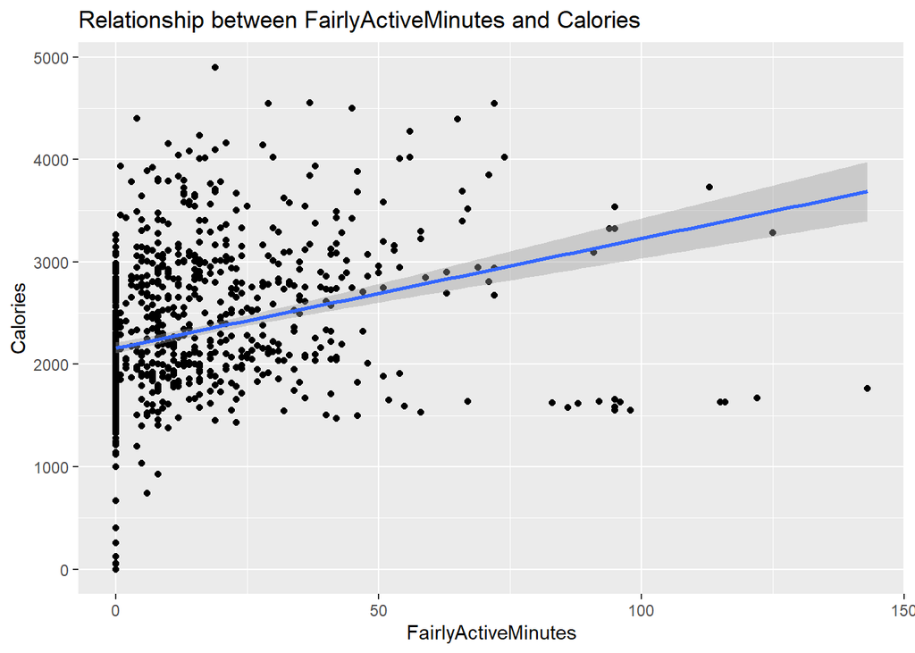

```r
ggplot(data = dailyActivity_cleaned) +
  geom_point(aes(x = FairlyActiveMinutes, y = Calories)) +
  geom_smooth(aes(x = FairlyActiveMinutes, y = Calories), method = "lm") +
  labs(title = "Relationship between FairlyActiveMinutes and Calories")
```

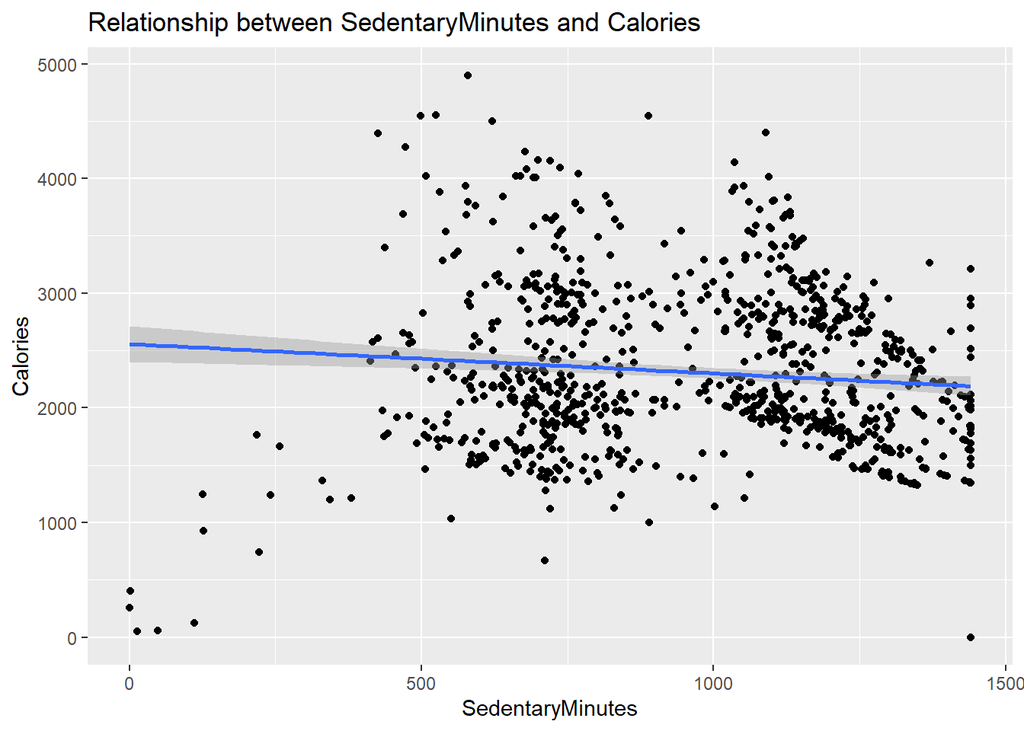

```r
ggplot(data = dailyActivity_cleaned) +
  geom_point(aes(x = SedentaryMinutes, y = Calories)) +
  geom_smooth(aes(x = SedentaryMinutes, y = Calories), method = "lm") +
  labs(title = "Relationship between SedentaryMinutes and Calories")
```

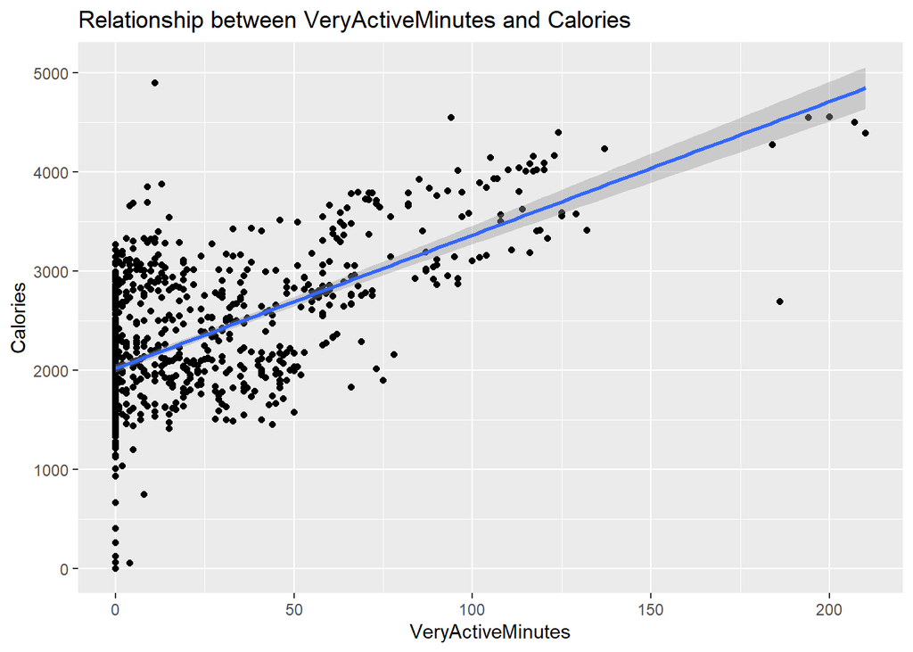

```r
ggplot(data = dailyActivity_cleaned) +
  geom_point(aes(x = VeryActiveMinutes, y = Calories)) +
  geom_smooth(aes(x = VeryActiveMinutes, y = Calories), method = "lm") +
  labs(title = "Relationship between VeryActiveMinutes and Calories")
```

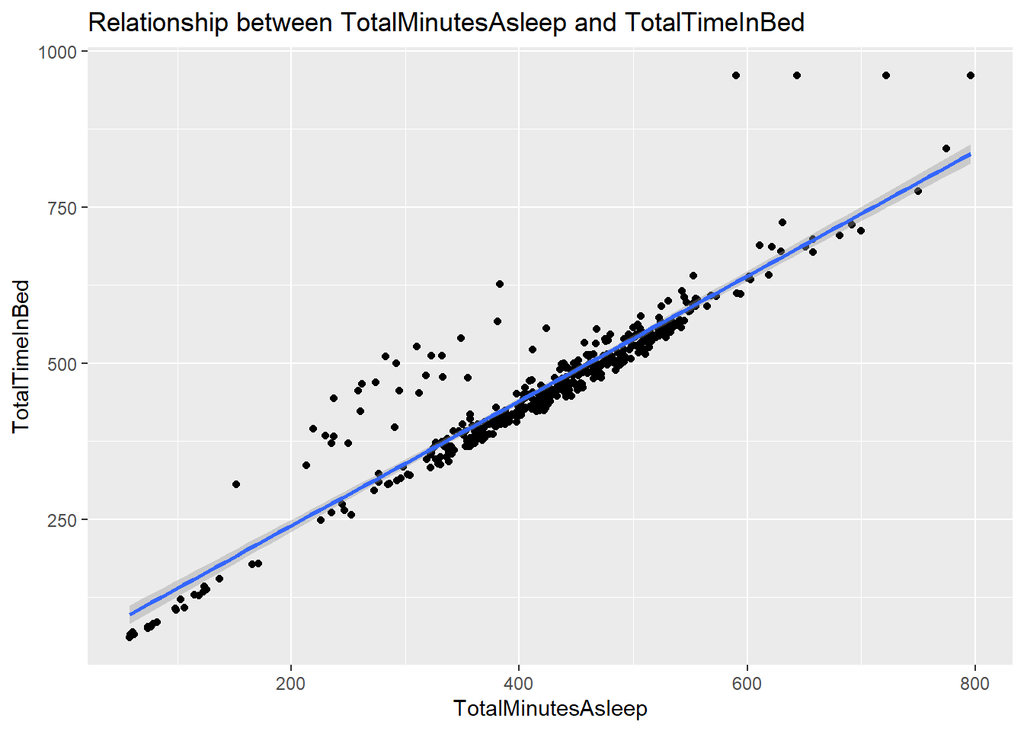

```r
ggplot(data = sleepDay_cleaned) +
  geom_point(aes(x = TotalMinutesAsleep, y = TotalTimeInBed)) +
  geom_smooth(aes(x = TotalMinutesAsleep, y = TotalTimeInBed), method = "lm") +
  labs(title = "Relationship between TotalMinutesAsleep and TotalTimeInBed")
```

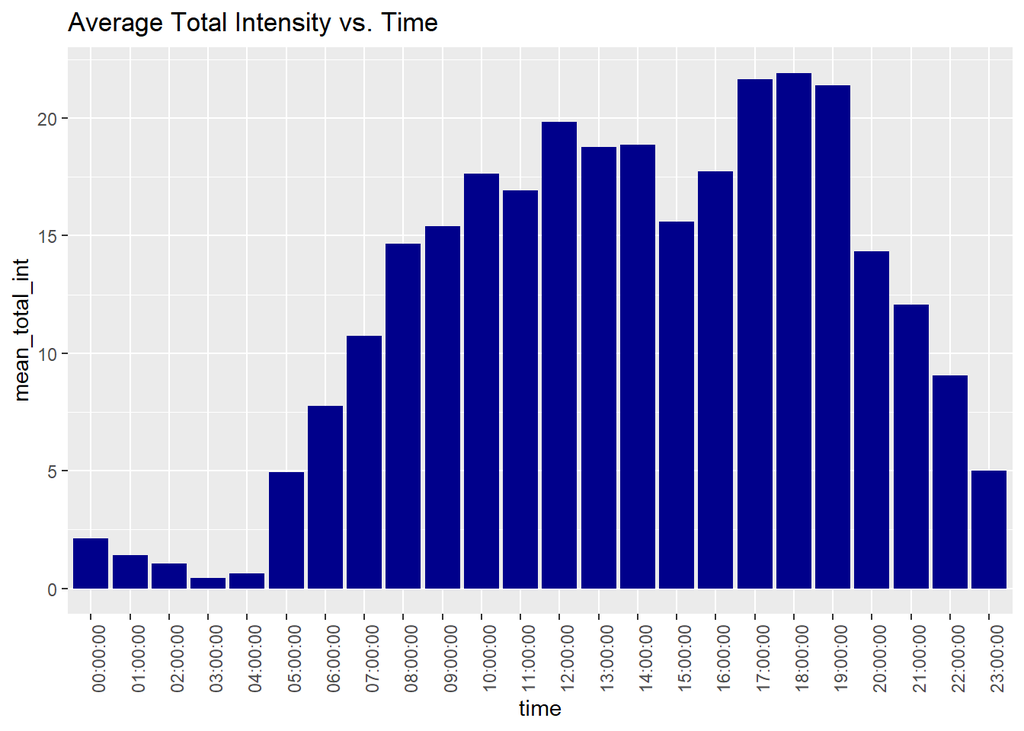

```r
int_new <- h_intensitie %>%
  group_by(time) %>%
  drop_na() %>%
  summarise(mean_total_int = mean(TotalIntensity))

ggplot(data=int_new, aes(x=time, y=mean_total_int)) + geom_histogram(stat = "identity", fill='darkblue') +
  theme(axis.text.x = element_text(angle = 90)) +
  labs(title="Average Total Intensity vs. Time")
```

- From the graph, we can conclude that people are more active between 5 am and 10 pm.
- Most activity happens between 5 pm and 7 pm. During this window, Bellabeat app can remind and motivate user to go for a run or walk.

```r
combined_sleep_activity <- merge(sleepDay_cleaned, dailyActivity_cleaned, by='Id')
head(combined_sleep_activity)
```

```
##           Id   SleepDay TotalSleepRecords TotalMinutesAsleep TotalTimeInBed
## 1 1503960366 2016-04-12                 1                327            346
## 2 1503960366 2016-04-12                 1                327            346
## 3 1503960366 2016-04-12                 1                327            346
## 4 1503960366 2016-04-12                 1                327            346
## 5 1503960366 2016-04-12                 1                327            346
## 6 1503960366 2016-04-12                 1                327            346
##     Date.x ActivityDate TotalSteps TotalDistance TrackerDistance
## 1 04/12/16     5/7/2016      11992          7.71            7.71
## 2 04/12/16     5/6/2016      12159          8.03            8.03
## 3 04/12/16     5/1/2016      10602          6.81            6.81
## 4 04/12/16    4/30/2016      14673          9.25            9.25
## 5 04/12/16    4/12/2016      13162          8.50            8.50
## 6 04/12/16    4/13/2016      10735          6.97            6.97
##   LoggedActivitiesDistance VeryActiveDistance ModeratelyActiveDistance
```

[output cut: 20 more lines]

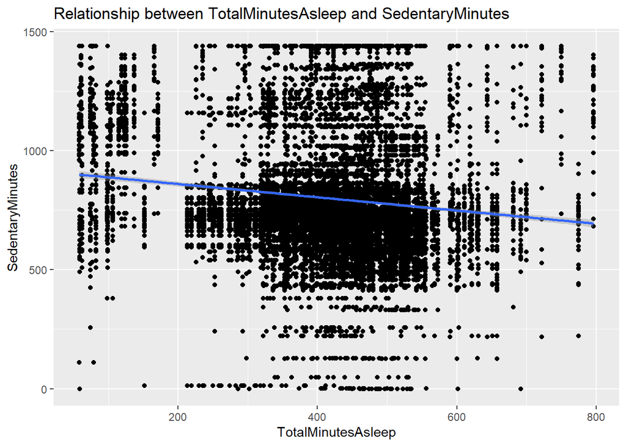

```r
ggplot(data = combined_sleep_activity) +
  geom_point(aes(x = TotalMinutesAsleep, y = SedentaryMinutes)) +
  geom_smooth(aes(x = TotalMinutesAsleep, y = SedentaryMinutes), method = "lm") +
  labs(title = "Relationship between TotalMinutesAsleep and SedentaryMinutes")
```

- From the graph, we can conclude that there exists a negative relationship between Minutes Asleep and Sedentary Minutes.
- To improve our customers’ sleep, Bellabeat app can recommend reducing sedentary time.
- To further analyse the situation, we need more data.

```r
combined_steps_calories <- merge(dailySteps, hourly_calories, by="Id")
glimpse(combined_steps_calories)
```

```
## Rows: 654,126
## Columns: 7
## $ Id           <dbl> 1503960366, 1503960366, 1503960366, 1503960366, 150396036…
## $ ActivityDay  <chr> "4/12/2016", "4/12/2016", "4/12/2016", "4/12/2016", "4/12…
## $ StepTotal    <dbl> 13162, 13162, 13162, 13162, 13162, 13162, 13162, 13162, 1…
## $ ActivityHour <dttm> 2016-04-12 00:00:00, 2016-04-12 01:00:00, 2016-04-12 02:…
## $ Calories     <int> 81, 61, 59, 47, 48, 48, 48, 47, 68, 141, 99, 76, 73, 66, …
## $ time         <chr> "00:00:00", "01:00:00", "02:00:00", "03:00:00", "04:00:00…
## $ date         <chr> "04/12/16", "04/12/16", "04/12/16", "04/12/16", "04/12/16…
```

[figure not shown]

```r
ggplot(data = combined_steps_calories,aes(x = Calories, y = StepTotal)) + geom_jitter()+
  geom_smooth(aes(x = Calories, y = StepTotal), method = "lm") +
  labs(title = "Hourly Calorie Burn and Hourly Step Count")
```

* From the graph, we can see that there exists a positive relationship between Calorie burn and Steps.

### Act Phase

Since its launch, Bellabeat has empowered women by offering information about their levels of activity, sleep, stress, hydration, and reproductive health. Bellabeat’s growth can be encouraged by making recommendations based on an analysis of Fitbit users’ behavior and feature responses.

The Bellabeat app needs to be entirely redesigned and updated. Instead of only offering health statistics, the app ought to motivate users to achieve their fitness objectives and function as a social media hub.

#### Recommendations for Bellabeat membership

- Promote Physical Activity: Utilize the Bellabeat app and wearables to motivate users with personalized challenges and reminders, fostering increased physical activity levels and healthier lifestyles.
- Improve Sleep Quality: Offer tailored sleep guidance and reminders to establish consistent sleep routines, enhancing overall sleep quality and well-being for users.
- Enhance Activity Tracking Features: Provide detailed insights into various activity intensities, empowering users to understand the relationship between their physical activity levels and overall health and fitness goals.
- Target Active Timeframes: Optimize marketing strategies and app features to capitalize on peak activity periods, such as between 5 pm and 7 pm, by delivering targeted motivational messages and workout suggestions.
- Ensure Data Accuracy: Maintain vigilance over data accuracy and reliability to uphold the integrity of insights derived from Bellabeat devices and apps, ensuring users receive accurate and actionable information.
- Tailored Marketing Campaigns: Tailor marketing campaigns to specific user segments based on demographics, engagement patterns, and health metrics, delivering personalized messages and content that resonate with users’ individual needs and preferences.
- Provide User Education and Support: Offer educational resources and support to help users better understand their health data, empowering them to make informed decisions and take control of their well-being.

By combining these strategies and recommendations, Bellabeat can not only communicate the importance of physical activity but also create an engaging and supportive ecosystem that motivates women to lead healthier lives with the help of Bellabeat products and services.